# Связь ориентации камбал с их размером в разных заливах Белого моря

В. Хайтов

24 03 2020

## Первичные данные

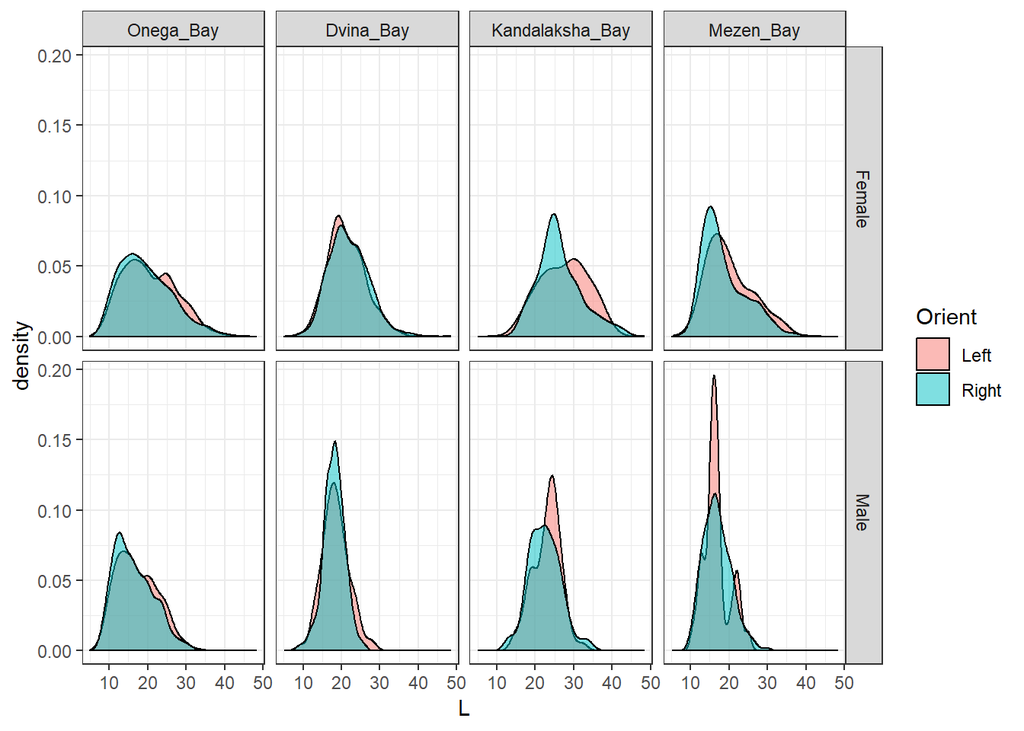

**Рисунок 1.** Частотное распределение размеров у рыб с разной ориентацией

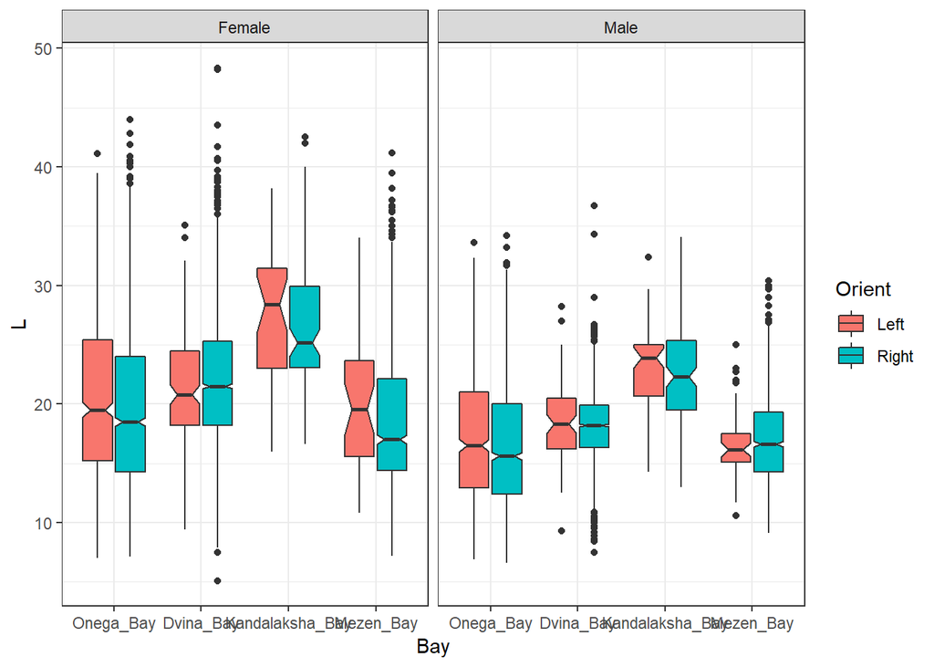

**Рисунок 2.** Размер рыб с разной ориентацией в разных заливах Белого моря.

Добавление Кандалакшского залива сделало тенденцию более заметной: левосторонние камбалы имеют большие размеры чем правосторонние.

## Размеры камбал с разной ориентацией

В принципе, можно привести вот такой анализ. Предположим, что нас интересует то, как связан размер камбалы и ее ориентация. Вот результаты дисперсионного анализа.

**Таблица 1.** Результаты дисперсионного анализа связи размеров камбал с ориентацией

| term | df | sumsq | meansq | statistic | p.value |
| --- | --- | --- | --- | --- | --- |
| Bay | 3 | 23507.449 | 7835.816 | 258.963 | 0.000 |
| Orient | 1 | 494.577 | 494.577 | 16.345 | 0.000 |
| Bay:Orient | 3 | 207.433 | 69.144 | 2.285 | 0.077 |
| Residuals | 12097 | 366036.870 | 30.258 | NA | NA |

Важно отметить, что значимого взаимодействия факторов “Ориентация” (Orient) и “Залив” (Bay) не наблюдается. Средние значения приведены на рисунке 1.

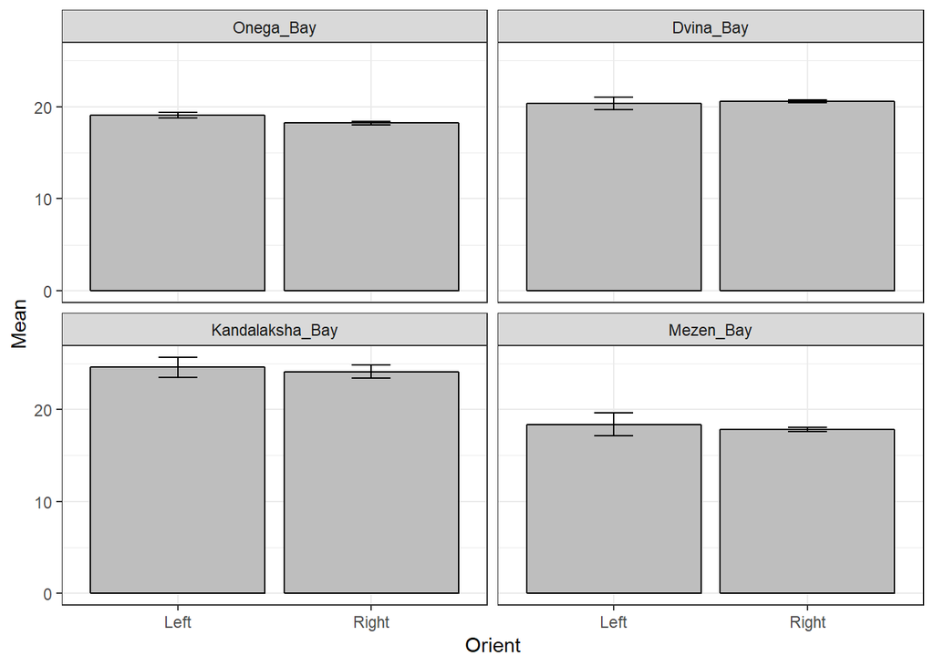

Рис. 1. Средняя длина рыб (усы демонстрируют 95% доверительный интервал) с разной ориентацией в разных заливах.

Надо будет еще критерием Тьюки сравнить средние, но сделаю это позднее.

Конечно, при столь незначительной разнице (хоть и статистически значимой) такая картинка не имеет смысла. Разве что видно, что в Кандалакше рыбы более крупные (по крайней мере в представленной выборке).

## Модель, описывающая связь вероятности встретить левостороннюю рыбу, с размером и полом.

Левосторонние камбалы рассматривались, как положительный исход (были кодированы, как “1”), правосторонние камбалы - как отрицательный исход (кодированы, как “0”).

Вот результаты подбора модели.

**Таблица 2.** Параметры регрессионной модели

| term | estimate | std.error | statistic | p.value |
| --- | --- | --- | --- | --- |
| (Intercept) | -1.484 | 0.136 | -10.882 | 0.000 |
| L | 0.020 | 0.006 | 3.165 | 0.002 |
| SexMale | -0.047 | 0.219 | -0.214 | 0.831 |
| BayDvina_Bay | -0.854 | 0.374 | -2.286 | 0.022 |
| BayKandalaksha_Bay | -0.478 | 0.966 | -0.495 | 0.621 |
| BayMezen_Bay | -2.756 | 0.580 | -4.750 | 0.000 |
| L:SexMale | 0.011 | 0.012 | 0.943 | 0.346 |
| L:BayDvina_Bay | -0.045 | 0.017 | -2.609 | 0.009 |
| L:BayKandalaksha_Bay | 0.016 | 0.035 | 0.459 | 0.646 |
| L:BayMezen_Bay | 0.021 | 0.027 | 0.777 | 0.437 |
| SexMale:BayDvina_Bay | -1.321 | 0.819 | -1.613 | 0.107 |
| SexMale:BayKandalaksha_Bay | 0.546 | 1.331 | 0.410 | 0.682 |
| SexMale:BayMezen_Bay | 1.284 | 0.976 | 1.316 | 0.188 |
| L:SexMale:BayDvina_Bay | 0.053 | 0.043 | 1.233 | 0.218 |
| L:SexMale:BayKandalaksha_Bay | -0.011 | 0.053 | -0.199 | 0.842 |
| L:SexMale:BayMezen_Bay | -0.070 | 0.053 | -1.309 | 0.191 |

Анализ девиансы показал, что явных признаков взаимодействия предикторов нет.

**Таблица 3.** Результаты анализа девиансы для полученной модели

|  | LR Chisq | Df | Pr(>Chisq) |
| --- | --- | --- | --- |
| L | 16.895 | 1 | 0.000 |
| Sex | 3.747 | 1 | 0.053 |
| Bay | 1226.016 | 3 | 0.000 |
| L:Sex | 1.062 | 1 | 0.303 |
| L:Bay | 6.101 | 3 | 0.107 |
| Sex:Bay | 5.902 | 3 | 0.116 |
| L:Sex:Bay | 3.497 | 3 | 0.321 |

В связи с этим можно провести упрощение модели в соответствии с протоколом backward selection: пошаговое удаление членов модели, при контроле значений AIC (Информационный критерий Акаике). Финальной моделью считалась модель с минимальным AIC.

AIC для полной модели составил 8444.4, после удаления лишних предикторов AIC финальной модели составил 8439.1. Последняя величина меньше, чем начальная, что говорит о том, что отброс лишних элементов привел к улучшению модели.

Вот параметры финальной модели.

**Таблица 4.** Параметры финальной модели

| term | estimate | std.error | statistic | p.value |
| --- | --- | --- | --- | --- |
| (Intercept) | -1.469 | 0.105 | -13.970 | 0.000 |
| L | 0.020 | 0.005 | 4.144 | 0.000 |
| SexMale | 0.123 | 0.059 | 2.081 | 0.037 |
| BayDvina_Bay | -1.895 | 0.074 | -25.596 | 0.000 |
| BayKandalaksha_Bay | 0.147 | 0.129 | 1.139 | 0.255 |
| BayMezen_Bay | -2.313 | 0.121 | -19.056 | 0.000 |

Вот ее анализ девиансы.

**Таблица 5.** Результаты анализа девиансы для финальной модели

|  | LR Chisq | Df | Pr(>Chisq) |
| --- | --- | --- | --- |
| L | 17.041 | 1 | 0.000 |
| Sex | 4.325 | 1 | 0.038 |
| Bay | 1227.736 | 3 | 0.000 |

Важно! Добавление данных Кандалакшского залива все-таки сместило модель в сторону статистической значимости пола. Среди самцов вероятность встретить левостороннюю особь немного выше, чем среди самок.

Для демонстрации полученных закономерностей визуализируем данную модель.

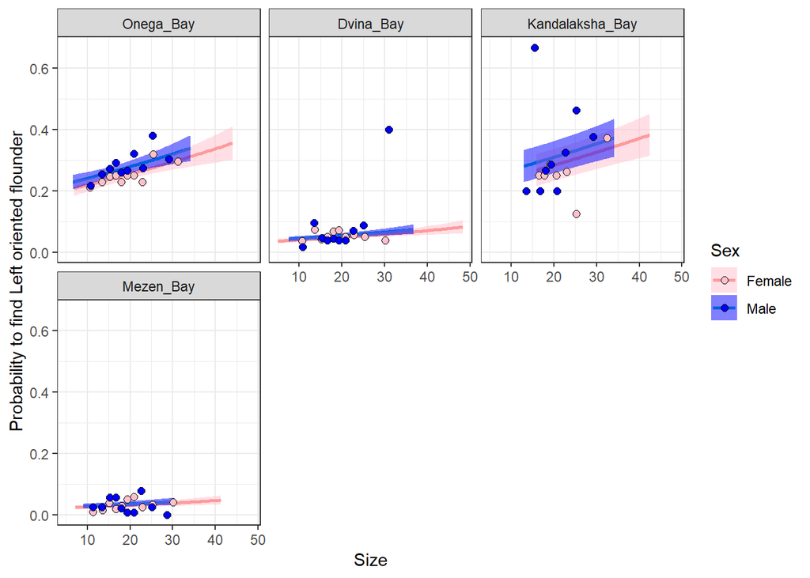

**Рисунок 3.** Зависимость вероятности встретить левостороннюю камбалу от размера у рыб в разных заливах Белого моря. Точками показаны частоты левосторонних особей в пределах раных размерных классов

Для оценки вероятности встречи левосторонних камбал в разных акваториях примем значение длины за среднее. Тогда вероятности встречи левосторонних камбал в разных заливах будут отражаться вот так.

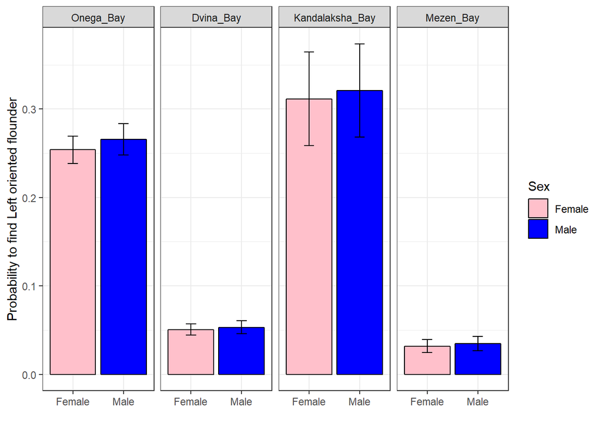

**Рисунок 4.** Вероятности встретить левостороннюю камбалу в разных заливах Белого моря (Усы отражают 95% доверительный интервал).

Видны следующие закономерности.

1. Вероятность встретить левостороннюю камбалу значимо выше в материале, собранном в Онежском и Кандалакшском заливе. Самая высокая в Кандалакше. В Мезенском заливе вероятность встречи такой камбалы минимальна.
2. Чем больше размер рыбы, тем больше вероятность встретить левостороннюю особь. И эта закономерность прослеживается во всех заливах.
3. Вероятность встретить левостороннюю особь статистически значимо, но очень слабо связана с полом: среди самцов левосторонние встречаются чуть-чуть чаще.

## Связь вероятности встретить левостороннюю особь с возрастом рыбы

Здесь все пока все не очень однозначно.

**Таблица 6.** Результаты анализа девиансы для модели, описывающей связь с возрастом

|  | LR Chisq | Df | Pr(>Chisq) |
| --- | --- | --- | --- |
| Age | 3.208 | 1 | 0.073 |
| Bay | 1055.894 | 2 | 0.000 |
| Age:Bay | 7.420 | 2 | 0.024 |

Здесь есть значимое взаимодействие между возрастом (Age) и заливом (Bay). Это означает, что напрямую связь с возрастом обсуждать нельзя. Можно только обсудить картинку, визуализирующую модель. Если смотреть на визуализацию модели, то очевидно, что в разных заливах тенденции разные. В Мезенском заливе связи, скорее, нет. В Двинском заливе есть тенденция к сокращению доли левосторонних с возрастом. В Онежском заливе явно читается обратная тенденция. Короче, я тут пока мало что понимаю.

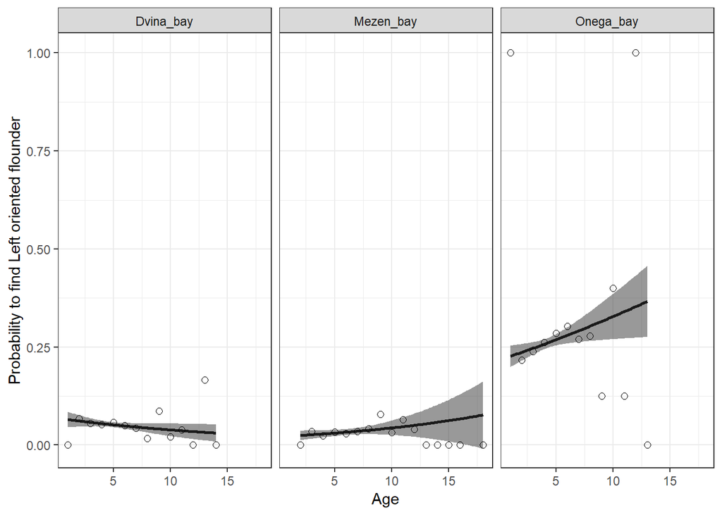